# Week 7 Practical: Estimating the heritability and additive genetic variance in a quantitative trait

Joel Pick

2025-03-05

Estimating additive genetic variance and heritability is key to predicting evolutionary response to selection, and the main focus of quantitative genetics. This practical demonstrates how to estimate heritability and additive genetic variance in a quantitative traits, using different statistical models.

**Aims:**

- understand what heritability represents and how we estimate it
- practice manipulating data in R
- practice plotting graphs in R
- learn how to fitting parent-offspring regressions, dam-sire models, and animal models
- estimate heritability

# Background

## Breeding values and additive genetic variance

In quantitative genetics, we often assume that their are an infinite number of genes that all have a tiny effect on the trait of interest. This is known as the infinitesimal model. It turns out this is an extremely powerful model, even when there are a few genes of large effect.

In terms of predicting response to selection, we are particularly interested in the *additive* genetic variance ($V_A$. This is the variance across individuals in the genetic values that they pass on to their offspring in an additive manner (i.e. the heritable component). If we think about a loci with two alleles (‘large’ and ‘small’) with a completely additive effect, having two ‘large’ alleles would have twice the effect on the phenotype as having one ‘large’ allele.

An individual’s genetic value, or *breeding value*, is the sum of the additive effects across all their loci. Under the infinitesimal model, and following the central limit theorem, we expect these breeding values to be normally distributed. An offspring’s *expected* breeding value is then the average of their parents. Their actual breeding value will be this average plus what is referred to as a *Mendelian sampling deviation*, which comes from recombination (i.e. not all offspring from a parent are genetically the same, as they will receive a random half of each parents alleles). This Mendelian sampling deviation is assumed to be normally distributed (following the central limit theorem), with a mean of 0 and a variance of half $V_A$.

## Principles of estimating $V_A$

The key to estimating additive genetic variation in a trait is to compare relatives.

The additive genetic variance can be estimated using the covariance between two sets of relatives. Assuming no other confounding factors (such as common environments; we will come to this later) the phenotypic covariance between two individuals is equal to their relatedness multiplied by the additive genetic variance.

So the expected phenotypic covariance between a parent (e.g. its mother) and their offspring, or between full siblings, is 0.5$V_A$, between half siblings, grandparents and grand-offspring, or between an individual and their aunt/uncle is 0.25$V_A$, between full cousins is 0.125$V_A$ and so on.

## Heritability

Often we want to present our estimate of $V_A$ as a heritability ($h^2$). The heritability of a trait is the *proportion* of the total phenotypic variance that can be ascribed to additive genetic variance. Heritability is useful for two reasons. First, it fits nicely into the breeders equation ($R=h^2S$), and so can be used directly to predict response to selection. Second, it provides a standardised measure of genetic variation, that varies between 0 and 1, and tells us about how much of the phenotypic variation we see is due to genetic variation among individuals. This makes it useful for making comparisons. It is worth noting that there is another standardised measure of genetic variance, known as evolvability, which is standardised by the phenotypic mean rather than the phenotypic variance. There is much debate about which is more appropriate, and I will not go into that here!

## Parent-Offspring regression

The traditional way of estimating heritability is through comparing the phenotypes of parents and offspring, using a parent-offspring regression. If you remember from the comparison of selection differentials and selection gradients, a regression slope is equal to Cov(x,y)/Var(x).

This relates nicely to the estimating heritability using a regression framework. When comparing a single parent and their offspring, we know that the covariance between them is equal to 0.5$V_A$. The genetic variance is then 2Cov(parent,offspring), and the heritability is 2Cov(parent,offspring)/Var(parent). As the regression slope is Cov(parent,offspring)/Var(parent), we can simple multiply the slope from a regression of offspring phenotypes on parent phenotypes by 2 to get an estimate of the heritability. In theory, we can do a similar thing for any relationship; multiply the regression coefficient by the inverse of the relatedness. So for grand-parent - grand-offspring regression, we would multiply the slope by 4.

### Mid-parent - offspring regression

As described above, the *expected* value of an offspring’s phenotype is the the mean of its parents. Consequently, if we use the mid-parent value (the mean of the parents phenotypes), then the covariance between the mid-parent and offspring values will estimate $V_A$. Put this another way - if all variation was genetic, then the slope between mid-parent and offspring values would be 1, as on average the offspring’s phenotype was completely predicted by the average of their parents phenotype. Note that, unless you had a very large number of offspring that you were averaging over, there would still be variation around the line due to Mendelian sampling variation.

## Sibling comparisons and the Dam-Sire model

Another powerful approach can be to compare sibling’s phenotypes. This is useful at it doesn’t require two generations of data (i.e. no parent data is needed). Full siblings are (on average) related by 0.5. They therefore provide a similar amount of information as parents and offspring, but a bit more noisy, as parents and offspring are related by exactly 0.5, whereas full siblings are related by 0.5 *on average* (some maybe identical, some may not share any genes).

To estimate the covariance among full-siblings, we can use mixed models to estimate among family variance. The resulting among family variance is then 0.5$V_A$. This is similar the full-sib analysis you used with the Yair data. There are, however, a few factors that can lead this to be biased. For example, dominance effects are shared by full siblings, as are some common environment effects, for example if the siblings have been raised together. These cannot be separated out in these models.

A common solution to this problem in animal breeding is to use ‘dam-sire models’, in combination with what is known as a half-sibling breeding design. In this kind of design, typically several males each are mated with multiple females. This produces lots of half-siblings, which do not share the dominance effects, and often not the common environment effects (or at least they do in a way that we can separate out more easily). To estimate $V_A$ using such a design, we run a mixed effects model with random effects of maternal and paternal IDs. The paternal (sire) variance represents 0.25$V_A$ (this is the comparison of paternal half-siblings, and so the sire variance represents the covariance between paternal half-siblings). In the absence of other effects, the maternal (dam) variance should be the same and also represent 0.25$V_A$(the covariance between maternal half-siblings).

In animal breeding, commonly species are used that provide substantial maternal (but not paternal) care (e.g. cows, pigs, sheep, chicken). We might then expect that offspring raised by the same *mother* might resemble each other more, if they receive similar care. This similarity between maternal sibling due to a shared maternal environment are known as maternal effects. If there are maternal effects, then we would expect the dam variance to be higher than then sire variance, as it would include both 0.25$V_A$ as well as the maternal effect variance ($V_M$). We can then estimate the maternal effect variance as the dam variance minus the sire variance.

## Animal models

Animal models are now the dominant way of estimating heritability in wild populations. They makes use of *all* the relationships in the pedigree. You can think of them as fitting models of all the different relationships simultaneously (think back to simultaneous equations from your school days!). This means that, with a good pedigree, it is a very powerful way of estimating additive genetic variance. Helpfully, these models provide a direct estimate of genetic variance straight from the model!

Animal models use a matrix of pairwise relatedness between all individuals in the population, known as the A matrix, which can be derived from the pedigree:

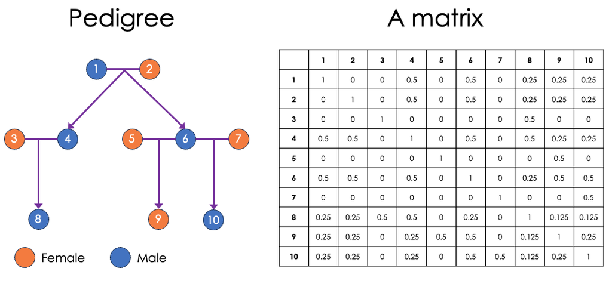

Use of the animal model for wild populations has really been driven by researchers from the Institute of Ecology and Evolution at the University of Edinburgh (notably, Loeske Kruuk, Jarrod Hadfield and Alastair Wilson (now at Exeter)). For an accessible introduction to use of animal model, see [Wilson et al. 2010. An ecologist’s guide to the animal model](https://doi.org/10.1111/j.1365-2656.2009.01639.x). There are also useful online tutorials at [here](https://wam-tutorial.github.io/en/) and [here](https://devillemereuil.legtux.org/wp-content/uploads/2021/09/tuto_en.pdf).

# Practical

## Red Deer Birth Weight

For this practical, we will again use data on the birth weight of red deer calves from the long-term study of red deer on the Isle of Rum, Inner Hebrides, Scotland. (For more details on the study, see: [Pemberton et al. 2022](https://doi.org/10.1146/annurev-ecolsys-012722-024041)). Today, we will specifically use data from [Gauzere et al. 2022](https://doi.org/10.1111/evo.14622), which is really cool study trying to understand selection and response to selection on birth weight in deer, and the role that maternal effects may play in this.

## Part 1: Set up

Download the csv files with the data and pedigree from Learn, and save in the appropriate place.

###Load packages

```r
# install.packages(c("nadiv","gremlin","pedtricks"))

library(pedtricks) # pedigree descriptions
library(nadiv)  # needed for creating inverse relatedness matrices
library(gremlin) # package for mixed models, and specifically animal models
library(scales)
```

###Load data First set your working directory, and then read in the data.

```r
setwd("~/Dropbox/0_Teaching/ERAC/week7_urbanisation/practical/")
deer_data<-read.csv('deer_dat_gauzere.csv')  # read in the data
deer_ped<-read.csv('deer_ped_gauzere.csv')  # read in deer pedigree
```

Have a look at the structure of the data

```r
str(deer_data)
```

```
## 'data.frame':    2484 obs. of  5 variables:
##  $ ID       : int  321 388 483 513 645 806 861 1056 1171 2082 ...
##  $ Mother   : int  397 396 537 2079 647 398 866 1063 1163 2084 ...
##  $ BirthYear: int  1974 1974 1974 1974 1974 1974 1974 1974 1974 1974 ...
##  $ Sex      : int  2 1 1 2 2 2 1 1 1 1 ...
##  $ BirthWt  : num  8.11 6.08 3.04 8.92 5.98 ...
```

```r
str(deer_ped)
```

```
## 'data.frame':    3073 obs. of  3 variables:
##  $ ID  : int  131 157 171 272 347 362 405 406 452 498 ...
##  $ Sire: int  NA NA NA NA NA NA NA NA NA NA ...
##  $ Dam : int  NA NA NA NA NA NA NA NA NA NA ...
```

The pedigree is typically represented as a 3 column data.frame with a column for the individual, their mother (dam) and their father (sire). The pedigree has records for all individuals within the pedigree, whether they have know parents or not (i.e. if they are included as a parent, they have to have a record). They are ordered so that parents come before offspring, and so you typically end up with lots of individuals at the top with no known parents, known as the base population. If we check the bottom of the pedigree, we can all the individuals have parents:

```r
tail(deer_ped)
```

```
##        ID Sire  Dam
## 3068 4848 2242  726
## 3069  416  959 4757
## 3070  418 4242 4757
## 3071  734 5573  466
## 3072  439  540  416
## 3073  438 5077  416
```

**Let’s consider the pedigree a little more. Work out how many unique mothers and fathers there are, and how many individuals only have one known parent. (click to get the solution)**

```r
#unique mothers and fathers
length(unique(deer_ped[,"Sire"]))
```

```
## [1] 476
```

```r
length(unique(deer_ped[,"Dam"]))
```

```
## [1] 747
```

```r
# missing mothers and fathers
sum(!is.na(deer_ped[,"Dam"]))
```

```
## [1] 2847
```

```r
sum(!is.na(deer_ped[,"Sire"]))
```

```
## [1] 2551
```

More individuals have an unknown father than an unknown mother. This is common in wild systems, as paternity assignment is more difficult compared with maternity assignment in systems where offspring stay with their mother. We also see that there are more unique mothers than fathers. Think back to the distributions of lifetime breeding success you saw last week - does this make sense?

We can use the `pedtricks` package to summarise and display the pedigree. We don’t have information in this pedigree file about the cohort of the individual, but we can visualise what we call pedigree depth, which shows the lineages:

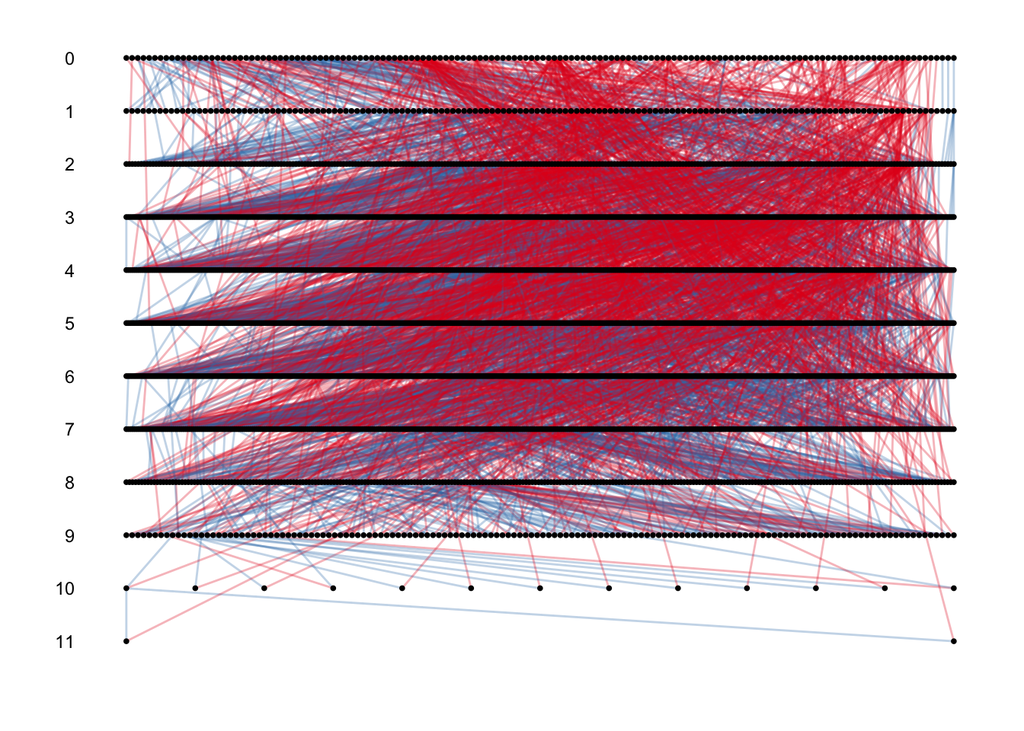

```r
ggpedigree(deer_ped)
```

The top row are the base population, those without known parents. As you can see there are a lot of long lineages. Given the intensity and length of the study, that it is an island population and females are very philopatric, this might be expected. We can also summarise the different relationships in the pedigree:

```r
stats <- ped_stats(deer_ped)
summary(stats)
```

```
##                                  sumData
## records                     3.073000e+03
## maternities                 2.847000e+03
## paternities                 2.551000e+03
## full sibs                   2.440000e+02
## maternal sibs               6.626000e+03
## maternal half sibs          6.382000e+03
## paternal sibs               1.526800e+04
## paternal half sibs          1.502400e+04
## maternal grandmothers       2.668000e+03
## maternal grandfathers       2.466000e+03
## paternal grandmothers       1.671000e+03
## paternal grandfathers       1.923000e+03
## maximum pedigree depth      1.100000e+01
## founders                    1.460000e+02
## mean maternal sibsip size   3.816354e+00
## mean paternal sibsip size   5.370526e+00
## non-zero F                  1.100000e+03
## F > 0.125                   2.300000e+01
## mean pairwise relatedness   1.857579e-02
## pairwise relatedness>=0.125 2.882782e-02
## pairwise relatedness>=0.25  8.051688e-03
## pairwise relatedness>=0.5   1.206323e-03
```

You can see that there is a lot of half sibling relationships in the pedigree compared to full siblings - what kind of mating system would produce this pattern?

## Part 2: Estimating heritability from parent-offspring regression

We will start by comparing the phenotypes of parents and offspring, using a parent offspring regression.

Let’s try and create three datasets, one to do father-offspring regression, one to do mother-offspring regression and a third for midparent-offspring regression.

**To do this we need to create datasets with mean offspring value per parent, or parent offspring combination, along with (mid) parent birthweights. Give this a go! (click to get the solution)**

```r
# to do with I have used functions in base R. You might be more familiar with other data manipulation packages.


## First we should add father ID to dataset from the pedigree
deer_data$Father <- deer_ped$Sire[match(deer_data$ID,deer_ped$ID)]

## then we can add both father and mother birthweight to the dataset. To do this we need to look them up by matching parents code to their record as an offspring
## add father birthweight to dataset
deer_data$fatherBirthWt <- deer_data$BirthWt[match(deer_data$Father,deer_data$ID)]

## add mother birthweight to dataset
deer_data$motherBirthWt <- deer_data$BirthWt[match(deer_data$Mother,deer_data$ID)]

## check what we have created
head(deer_data)
```

```
##    ID Mother BirthYear Sex BirthWt Father fatherBirthWt motherBirthWt
## 1 321    397      1974   2    8.11     NA            NA            NA
## 2 388    396      1974   1    6.08     NA            NA            NA
## 3 483    537      1974   1    3.04   4357            NA            NA
## 4 513   2079      1974   2    8.92   5110            NA            NA
## 5 645    647      1974   2    5.98     NA            NA            NA
## 6 806    398      1974   2    9.07     NA            NA            NA
```

```r
# then get the mean offspring weight per mother (and single value for mother birth weight):
offspring_means_M <- aggregate(cbind(BirthWt,motherBirthWt) ~ Mother, deer_data, mean)

# same for fathers
offspring_means_F <- aggregate(cbind(BirthWt,fatherBirthWt) ~ Father, deer_data, mean)

# and the same for parent pairs
offspring_means_mid <- aggregate(cbind(BirthWt,fatherBirthWt,motherBirthWt) ~ Mother+Father, deer_data, mean)
# and then average across parent phenotypes to get mid parent value
offspring_means_mid$midparentBirthWt <- (offspring_means_mid$motherBirthWt + offspring_means_mid$fatherBirthWt)/2

#Lets check what we have created
head(offspring_means_M)
```

```
##   Mother  BirthWt motherBirthWt
## 1     35 7.720000         7.710
## 2     36 5.746667         6.895
## 3     43 5.345000         7.120
## 4     48 7.730000         6.280
## 5     51 6.430000         6.540
## 6     58 5.955000         4.475
```

```r
head(offspring_means_F)
```

```
##   Father  BirthWt fatherBirthWt
## 1     52 6.377778         7.225
## 2     97 7.140000         6.180
## 3    174 6.804286         7.140
## 4    189 6.603333         6.280
## 5    196 5.921111         7.450
## 6    199 5.265000         5.440
```

```r
head(offspring_means_mid)
```

```
##   Mother Father BirthWt fatherBirthWt motherBirthWt midparentBirthWt
## 1   1918     52    6.11         7.225         5.725           6.4750
## 2   2991     52    6.30         7.225         6.920           7.0725
## 3   3032     52    7.74         7.225         7.080           7.1525
## 4   4473     52    8.84         7.225         6.240           6.7325
## 5   4475     52    7.02         7.225         6.040           6.6325
## 6   5135     52    8.08         7.225         7.780           7.5025
```

We can then look at these relationships:

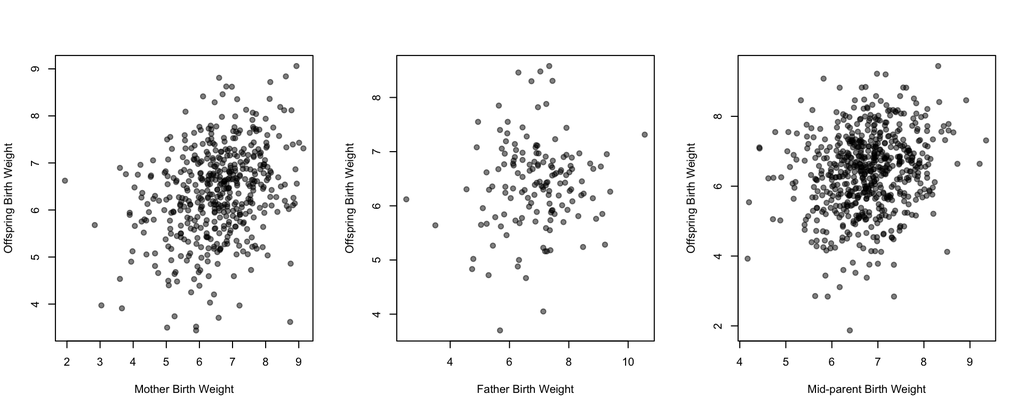

```r
par(mfrow=c(1,3))
plot(BirthWt~motherBirthWt,offspring_means_M, pch=19, col=alpha(1,0.5), xlab="Mother Birth Weight", ylab="Offspring Birth Weight")
plot(BirthWt~fatherBirthWt,offspring_means_F, pch=19, col=alpha(1,0.5), xlab="Father Birth Weight", ylab="Offspring Birth Weight")
plot(BirthWt~midparentBirthWt,offspring_means_mid, pch=19, col=alpha(1,0.5), xlab="Mid-parent Birth Weight", ylab="Offspring Birth Weight")
```

Just from looking at the plot of the relationship between parents and offspring, what would you predict qualitatively about whether birth weight is a heritable trait?

We will now estimate the heritability of height in this data-set using a parent-offspring regression. Reminder: the heritability of a trait is the *proportion* of the total phenotypic variance that can be ascribed to additive (heritable) genetic variance. It should be a value between 0 and 1.

We’ll first estimate the slope from first principles. The slope of a linear regression is given by the formula:

slope = covariance(parents,offspring)/variance(parents).

**Estimate the slope of the midparent-offspring regression using this formula and the values calculated above (click to get the solution)**

```r
v = var(offspring_means_mid$midparentBirthWt)
c = cov(offspring_means_mid$midparentBirthWt,offspring_means_mid$BirthWt)
c/v
```

```
## [1] 0.289516
```

**Now estimate the slope using a linear regression, and plot it with confidence intervals (click to get the solution).**

```r
lm_po <- lm(BirthWt~midparentBirthWt,offspring_means_mid)
summary(lm_po)
```

```
##
## Call:
## lm(formula = BirthWt ~ midparentBirthWt, data = offspring_means_mid)
##
## Residuals:
##     Min      1Q  Median      3Q     Max
## -4.4145 -0.7170  0.0696  0.7334  2.9605
##
## Coefficients:
##                  Estimate Std. Error t value Pr(>|t|)
## (Intercept)       4.43449    0.39441  11.243  < 2e-16 ***
## midparentBirthWt  0.28952    0.05783   5.006 7.28e-07 ***
## ---
## Signif. codes:  0 '***' 0.001 '**' 0.01 '*' 0.05 '.' 0.1 ' ' 1
##
## Residual standard error: 1.102 on 609 degrees of freedom
## Multiple R-squared:  0.03953,    Adjusted R-squared:  0.03795
## F-statistic: 25.06 on 1 and 609 DF,  p-value: 7.28e-07
```

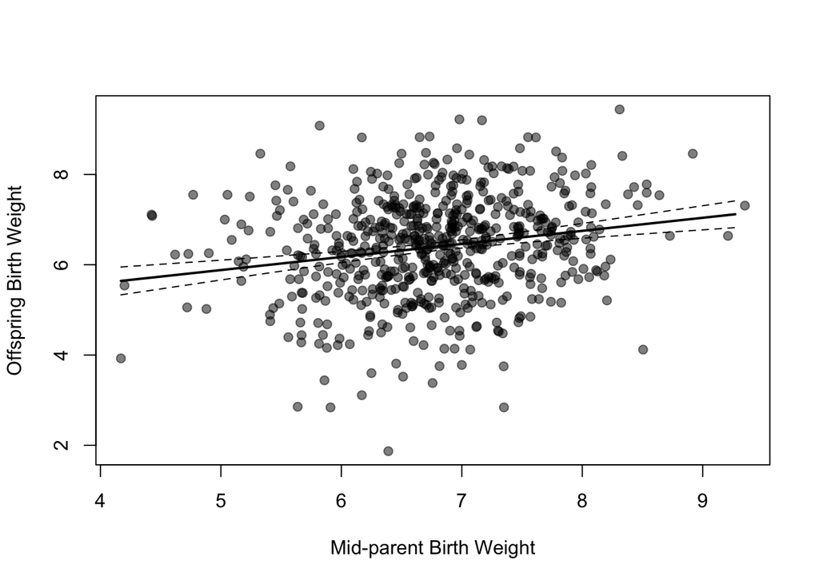

```r
plot(BirthWt~midparentBirthWt,offspring_means_mid, pch=19, col=alpha(1,0.5), xlab="Mid-parent Birth Weight", ylab="Offspring Birth Weight")

# make data to predict from
newdat <- data.frame(midparentBirthWt=seq(min(offspring_means_mid$midparentBirthWt),max(offspring_means_mid$midparentBirthWt),0.1))

#make predictions from model with confidence intervals
preds<-predict(lm_po, newdata=newdat,interval = "confidence")

# add lines
lines(newdat$midparentBirthWt,preds[,"fit"], lwd=2)
lines(newdat$midparentBirthWt,preds[,"lwr"], lty=2)
lines(newdat$midparentBirthWt,preds[,"upr"], lty=2)
```

We have fitted a model of y = a + b * x, where y is offspring birthweight and x is mid-parent birthweight. For this line, *a* is the Intercept in the above output, and *b* is the slope coefficient next to midparentBirthWt. As discussed above, this slope is an estimate of the *heritability* of birth weight

```r
h2_po <- summary(lm_po)$coeff[2,1:2]
print(round(h2_po,3))
```

```
##   Estimate Std. Error
##      0.290      0.058
```

Let’s see what we get if we look at the single parent offspring regressions. Note that we need to double the value of the slope from these models, as the relatedness between a parent and its offspring is 0.5.

**Give this a go (click to get the solution).**

```r
# mother offspring
lm_mo <- lm(BirthWt~motherBirthWt,offspring_means_M)
summary(lm_mo)$coeff[2,1:2]*2
```

```
##   Estimate Std. Error
## 0.51657408 0.07464579
```

```r
# father offspring
lm_fo <- lm(BirthWt~fatherBirthWt,offspring_means_F)
summary(lm_fo)$coeff[2,1:2]*2
```

```
##   Estimate Std. Error
##  0.1230888  0.1150454
```

These two regressions give very different answers. Why might this be? What might lead to the resemblance between mothers and offspring being larger than fathers and their offspring?

## Part 3: Estimating heritability from a dam-sire model

Due to the mating system of the red deer, we have loads of half-siblings in this population, so we can also estimate heritability using a dam-sire model.

To do this we fit a mixed model with mother and father IDs as random terms. Last week we used the `lme4` package to do this. This week we will use the package `gremlin`, which will allow us to fit animal models later on.

As we did last week, we will also fit effects of sex and birth year (as fixed and random, respectively) to account for variation in these factors that might affect our estimation of $V_A$.

```r
# make factors for gremlin
deer_data$Sex<-as.factor(deer_data$Sex)
deer_data$BirthYear<-as.factor(deer_data$BirthYear)
deer_data$Father<-as.factor(deer_data$Father)
deer_data$Mother<-as.factor(deer_data$Mother)
deer_data$ID<-as.factor(deer_data$ID)

# in gremlin we need a dataset without NAs, but we have missing fathers in our dataset. We can therefore subset the data to remove those that don't have a father
father_subset<- subset(deer_data, !is.na(Father))

# a gremlin model is very similar, but we have different arguments for fixed and random effects. The argument 'v' tells gremlin how much information to print when running the model - these model are fairly simple so we will tell it not to output the information (v=0).
ds1 <- gremlin(BirthWt ~ Sex,
  random = ~ BirthYear + Mother + Father,
  data = father_subset,v=0)
summary(ds1)
```

```
##
##  Linear mixed model fit by REML [' gremlin ']
##  REML log-likelihood: -1263.736
##   lambda: FALSE
##
##  elapsed time for model: 0.0803
##
##  Scaled residuals:
##     Min      1Q  Median      3Q     Max
## -3.0366 -0.4877  0.0629  0.5612  3.3422
##
##  (co)variance parameters: ~BirthYear + Mother + Father
##          rcov: ~units
##             Estimate Std. Error
## G.BirthYear  0.08209    0.02315
## G.Mother     0.59041    0.05137
## G.Father     0.06856    0.01828
## ResVar1      0.76613    0.02956
##
##  (co)variance parameter sampling correlations:
##             G.BirthYear  G.Mother G.Father  ResVar1
## G.BirthYear    1.000000  0.004324 -0.02284 -0.03112
## G.Mother       0.004324  1.000000 -0.02266 -0.17878
## G.Father      -0.022844 -0.022656  1.00000 -0.23248
## ResVar1       -0.031122 -0.178783 -0.23248  1.00000
##
##  Fixed effects: BirthWt ~ Sex
##             Estimate Std. Error z value
## (Intercept)   6.2808    0.06383   98.40
## Sex2          0.3247    0.04318    7.52
```

We are mostly interested in ‘(co)variance parameters’ part. We can also specifically return this bit:

```r
summary(ds1)$varcompSummary
```

```
##               Estimate Std. Error
## G.BirthYear 0.08209056 0.02314828
## G.Mother    0.59041087 0.05136812
## G.Father    0.06855863 0.01827608
## ResVar1     0.76612719 0.02956297
```

The dam and sire variances differ quite considerable here. Why might this be?

We can then calculate $V_A$ and $h^2$. As discussed above, $V_A$ is four times sire variance, and the maternal variance ($V_M$) is the dam variance minus the sire variance. From these we can then estimate $h^2$ and the proportion of total variance due to maternal effects ($m^2$). It is a bit convoluted to get standard on these derived estimates, but `gremlin` has a function for this, using the what is known as the delta method. We can specify this as follows:

```r
h2_ds <- deltaSE(list(
  h2 ~ V3*4 / (V1 + V2 + V3 + V4),
  m2 ~ (V2-V3) / (V1 + V2 + V3 + V4)
  ), ds1)
h2_ds
```

```
##     Estimate Std. Error
## h2 0.1819512 0.04785206
## m2 0.3462425 0.02914028
```

Here, we give a list of calculations for the parameters we want to calculate. We provide the calculation as a formula, telling it which component to use, so V1 is the first random term which here is BirthYear, V2 is the second and so on.

## Part 4: Estimating heritability from an animal model

We will now estimate heritability with an *animal model*. This is a more complex model than a parent-offspring regression or the half-sib analysis you used above: it uses information on all types of relatives simultaneously from across a whole pedigree, not just parents and offspring, or just siblings. This means that to fit an animal model, `gremlin` needs information from the pedigree as well as trait data.

Essentially, an animal model is just like any other mixed model but with an additional random effect of an individual’s “genetic merit” (or “breeding value”). The variance-covariance structure for this random effect is determined by the pedigree, which gives information on how related individuals are. This relatedness information is summarised by a relatedness matrix, A, which contains the pairwise relatedness between all pairs of individuals in the pedigree. To fit the model, `gremlin` needs the *inverse* of this matrix, which you create with the command below.

```r
Ainv <- makeAinv(deer_ped)$Ainv
```

We can then fit an animal model with `gremlin`. The only difference with the model specification above is that we link the inverse A matrix to one of our random terms (here ID) using the `ginverse` argument.

```r
am1 <- gremlin(BirthWt ~ Sex,
  random = ~ BirthYear + ID,
  ginverse = list(ID = Ainv),
  data = deer_data, v=0)
summary(am1)$varcompSummary
```

```
##               Estimate Std. Error
## G.BirthYear 0.08150956 0.02252049
## G.ID        0.75609501 0.07001357
## ResVar1     0.68759102 0.04632851
```

Most of the variation here is explained the ID term, which is a direct estimate of the additive genetic variation. The heritability is then proportion of the total phenotypic variance that is due to additive genetic variance.

**Try and calculate this based on the code above (click to get the solution).**

```r
h2_am1 <- deltaSE(list(
  h2 ~ V2 / (V1 + V2 + V3)
  ), am1)
h2_am1
```

```
##     Estimate Std. Error
## h2 0.4957364 0.03621451
```

This heritability is much higher than in the dam-sire model. Why might this be? What are we accounting for in the dam-sire model, that we haven’t accounted for here?

In this system, mothers care extensively for their calves. We might therefore expect there to be consistent effects of a mother on her offspring, i.e., maternal effects. A lot of information about relatedness in this pedigree comes from maternal siblings (see pedigree metrics calculated at the beginning). By not accounting for the shared maternal environment, we might be upwardly biasing our estimate of $h^2$ in this model.

**How might we account for these maternal effects? Run another model that will give less biased estimate of $V_A$ (click to get the solution).**

```r
am2 <- gremlin(BirthWt ~ Sex,
  random = ~ BirthYear + ID + Mother ,
  ginverse = list(ID = Ainv),
  data = deer_data)
```

```
## gremlin started:      09:02:00
##   1 of max 20        lL:-2683.119320     took 0.0414 sec.
##   2 of max 20        lL:-1475.925600     took 0.0376 sec.
##   3 of max 20        lL:-1431.837914     took 0.0370 sec.
##   4 of max 20        lL:-1429.951424     took 0.0396 sec.
##   5 of max 20        lL:-1429.946203     took 0.0397 sec.
##   6 of max 20        lL:-1429.946202     took 0.0378 sec.
##   7 of max 20        lL:-1429.946202     took 0.0380 sec.
##   8 of max 20        lL:-1429.946202     took 0.0372 sec.
##
## ***  REML converged  ***
##
## gremlin ended:        09:02:01
```

```r
summary(am2)$varcompSummary
```

```
##               Estimate Std. Error
## G.BirthYear 0.07316006 0.01975317
## G.ID        0.35257578 0.06400166
## G.Mother    0.44330983 0.04490823
## ResVar1     0.61272005 0.04359066
```

```r
h2_am2 <- deltaSE(list(
  h2_am2 ~ V2 / (V1 + V2 + V3 + V4),
  m2_am2 ~ V3 / (V1 + V2 + V3 + V4)
  ), am2)
h2_am2
```

```
##         Estimate Std. Error
## h2_am2 0.2379430 0.04083645
## m2_am2 0.2991767 0.02523591
```

This shows large differences between mothers, over and above the additive genetic (or ‘direct genetic’) component of variance. This matches with the results from our dam-sire model above.

(Aside: with more complicated models, we can show that this variance between mothers also has a genetic component, known as ‘maternal genetic variance’.)

## Comparing different methods

We can put all these different estimates together and compare them

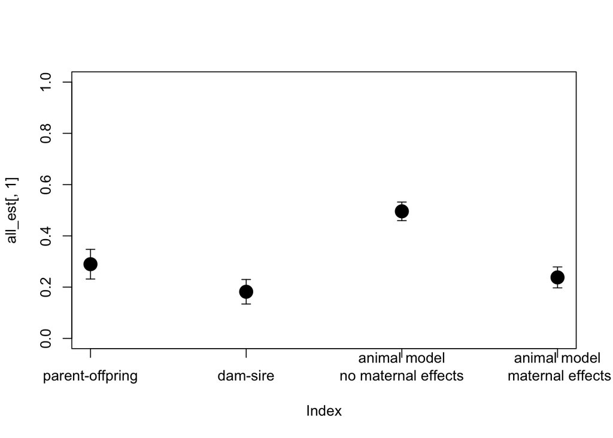

```r
#Make a matrix with all the results
all_est <- rbind(po=h2_po,ds=h2_ds[1,],am1=h2_am1[1,],am2=h2_am2[1,])

#plot them
plot(all_est[,1], pch=19, cex=2, ylim=c(0,1), xaxt="n")
axis(1,1:4, c("parent-offpring","dam-sire","animal model\nno maternal effects","animal model\n maternal effects"))
arrows(1:4,all_est[,1]+all_est[,2],1:4,all_est[,1]-all_est[,2], code=3, angle=90, length=0.05)
```

The animal model without accounting for maternal effects gives a clearly inflated estimate, but the other three methods give broadly similar results.

## Predicting selection response

Based on last weeks practical, we know that selection is acting on birth weight in this population. From these analyses, we can conclude that it is also heritable. With these estimates, we can parametrise the breeders equation ($R=h^2S$), and predict how rapidly we should expect birth weight to increase.